# STAT 185 - Problem Set #5

Matt Krasnow

## Instructions

This assignment covers nonlinear manifold learning (ISOMAP and LLE) through a mixture of theory and coding. You will need the file *pset5.Rdata* available on Canvas. The commands for loading the data assume this file, *pset5.Rmd*, and the Rdata file are in the same folder. Unfortunately, there is not one R package that provides each of the dimension reduction methods we’ve discussed in class.

We will be using the **Rdimtools** package to implement some of the methods, which has a general form **out <- do.method(X,ndim = d, type = c(“knn”,k))**. The output dimension is specified by the variable $d$, the number of nearest neighbors is *k*, and the lower dimensional representation is contain in out$Y. For ISOMAP, use do.iosmap and for Laplacian Eigenmaps, use do.lapeig. For Laplacian eigenmaps, you can specify the bandwidth $\sigma^2$ by adjusting **kernelscale** in the command for LEs.

For Hessian Local Linear Embeddings, we’ll use the **dimRed** package, which requires the command **out<-embed(X,ndim = d, “HLLE”, knn = k)** to use *k* nearest neighbors Complete the following questions and submit your solutions as a *pdf* via Canvas by 11:59 PM on Friday November 14th.

## Problems

### Problem 0

Please indicate your topic for the final report and oral exam.

Manifold learning for High-Dimensional Energy Optimization. I want to investigate the methods and do a short investigation on the IRED energy trajectories from https://energy-based-model.github.io/ired/

### Problem 1

The variable *faces* contains 33 images ($112\times 92$ pixels) of a person taken at different angles. The data were obtained (and modified slightly) from the [github repository](https://yao-lab.github.io) maintained by Yuan Yao. Three images are shown below.

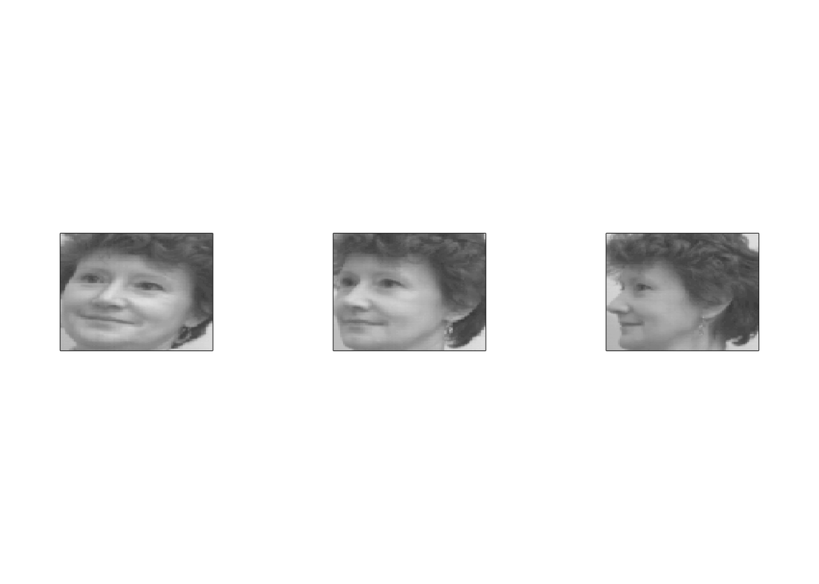

```r
par(pin = c(1.3,1), mfrow = c(1,3))
for (j in c(1,30,25)){
  plot_face(faces[j,])
}
```

Each image is a function of the angle of the camera used to take the picture so it is natural to expect the data reside on a one dimensional manifold. Let’s investigate that assumption. For each sample, $\vec{x}_i$, compute its five nearest neighbors $\vec{x}_{i_1},\dots,\vec{x}_{i_5}$. Then compute and save the nonzero singular values of
$${\bf M}_i =
\begin{bmatrix}\vec{x}_{i_1}^T-\vec{x}_{i}^T \\ \vdots \\
\vec{x}_{i_5}^T-\vec{x}_{i_1}^T\end{bmatrix}.$$

1. Generate boxplots of the singular values. Do these results suggests (or at least agree with the assumption) that the data reside on a one-dimensional manifold?

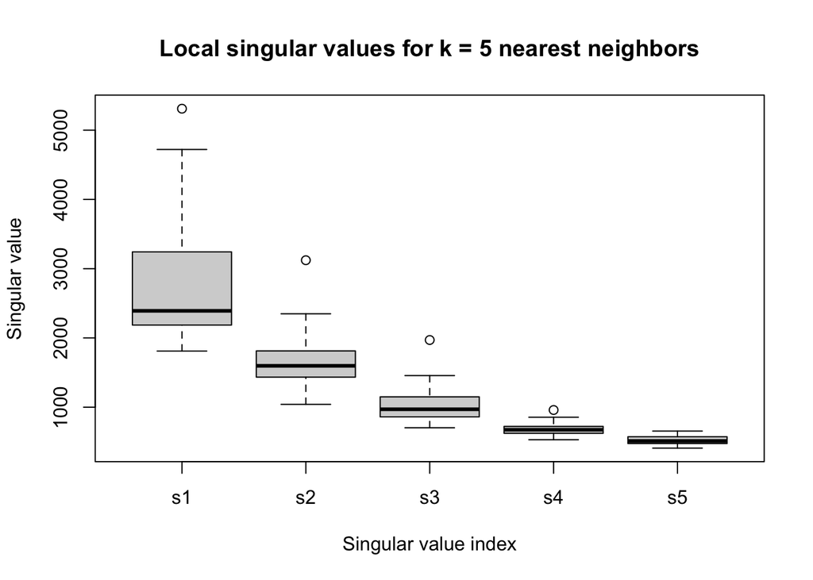

```r
k <- 5
n <- nrow(faces)

knn_res <- KernelKnn::knn.index.dist(as.matrix(faces), k = k)
nn_idx  <- knn_res$train_knn_idx   # n x k matrix of neighbor indices
singvals <- matrix(NA_real_, nrow = n, ncol = k)

for (i in 1:n) {
  x_i   <- faces[i, ]
  neigh <- faces[nn_idx[i, ], , drop = FALSE]

  M_i <- sweep(neigh, 2, x_i, FUN = "-")

  s <- svd(M_i)$d

  # store up to k singular values
  singvals[i, 1:min(length(s), k)] <- s[1:min(length(s), k)]
}

colnames(singvals) <- paste0("s", 1:k)

boxplot(as.data.frame(singvals),
        xlab = "Singular value index",
        ylab = "Singular value",
        main = "Local singular values for k = 5 nearest neighbors")
```

2. If you use $k=10$ or $k=20$ nearest neighbors, do your results change? What is a potential reason for these results?

[figure not shown]

```r
k <- 20
n <- nrow(faces)

knn_res <- KernelKnn::knn.index.dist(as.matrix(faces), k = k)
nn_idx  <- knn_res$train_knn_idx   # n x k matrix of neighbor indices
singvals <- matrix(NA_real_, nrow = n, ncol = k)

for (i in 1:n) {
  x_i   <- faces[i, ]
  neigh <- faces[nn_idx[i, ], , drop = FALSE]

  M_i <- sweep(neigh, 2, x_i, FUN = "-")

  s <- svd(M_i)$d

  # store up to k singular values
  singvals[i, 1:min(length(s), k)] <- s[1:min(length(s), k)]
}

colnames(singvals) <- paste0("s", 1:k)

boxplot(as.data.frame(singvals),
        xlab = "Singular value index",
        ylab = "Singular value",
        main = "Local singular values for k = 5 nearest neighbors")
```

### Problem 2

However, choosing a manifold learning method for the *faces* data is less clear. In this problem, we’ll choose among HLLEs, Laplacian Eigenmaps (LEs), and ISOMAP while the tuning of the number of nearest neighbors.

The helper function **neighbor_match(X,Y,k)** takes in a high-dimensional data matrix $X$, a lower dimensional data matrix, $Y$, given by a dimension reduction algorithm, and a specified number of neighbors $k$ and returns the average proportion of the $k$ nearest neighbors preserved between $X$ and $Y$. A neighbor_match of 0 is poor and 1 is good.

Plot the neighborhood match score for each method (HLLE, LE, ISOMAP) as a function of the number of nearest neighbors. For technical reasons, $k \ge 3$ for the algorithms to work. Use the default bandwidth for the rbf kernel in LEs. Based on these results, which method and value of $k$ do you choose? Explain your reasoning.

```r
k_vals   <- 3:10
methods  <- c("HLLE", "LE", "ISOMAP")
nm_scores <- matrix(NA_real_, nrow = length(k_vals), ncol = length(methods))
colnames(nm_scores) <- methods

faces_df      <- as.data.frame(faces)
faces_dimred  <- dimRedData(faces_df)

for (i in seq_along(k_vals)) {
  k <- k_vals[i]

  ## HLLE
  hlle_try <- try(
    embed(faces_dimred, "HLLE", knn = k, ndim = 2),
    silent = TRUE
  )

  if (!inherits(hlle_try, "try-error")) {
    Y_hlle <- as.matrix(hlle_try@data@data[, 1:2])
    nm_scores[i, "HLLE"] <- neighbor_match(faces, Y_hlle, k)
  } else {
    nm_scores[i, "HLLE"] <- NA_real_
  }

  ## Laplacian Eigenmap
  le_res <- do.lapeig(faces, ndim = 2, type = c("knn", k))
  Y_le   <- le_res$Y
  nm_scores[i, "LE"] <- neighbor_match(faces, Y_le, k)

  ## ISOMAP
  iso_res <- do.isomap(faces, ndim = 2, type = c("knn", k))
  Y_iso   <- iso_res$Y
  nm_scores[i, "ISOMAP"] <- neighbor_match(faces, Y_iso, k)
}
```

[output not shown]

[output not shown]

[output not shown]

[output not shown]

[output not shown]

[output not shown]

[output not shown]

[output not shown]

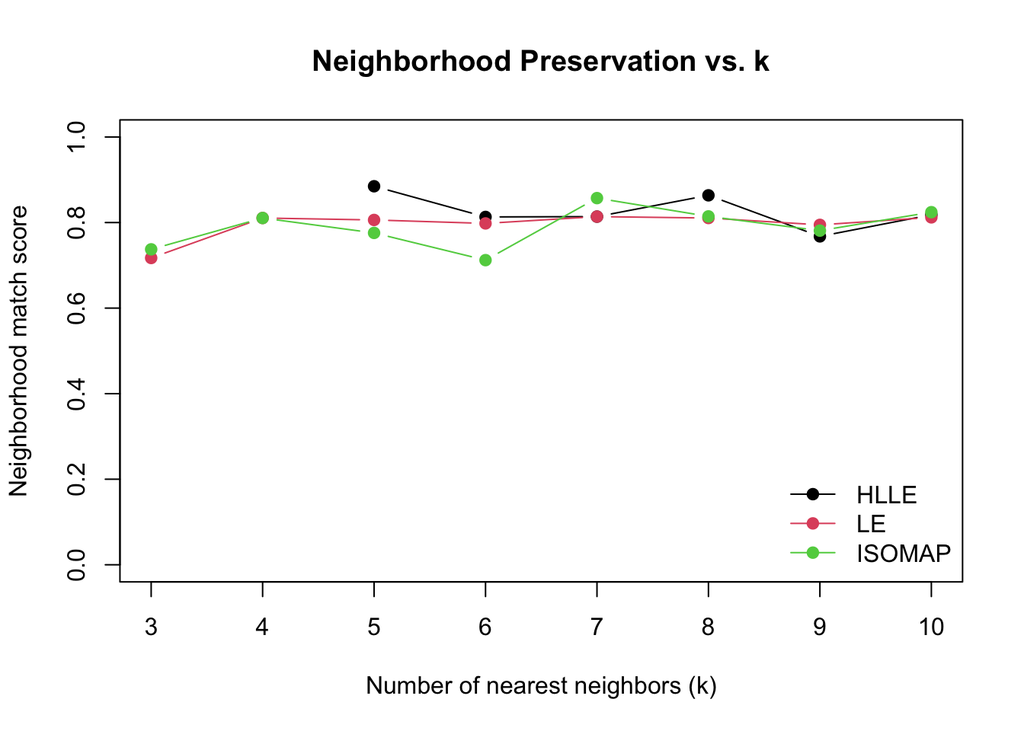

```r
matplot(
  k_vals, nm_scores,
  type = "b", pch = 19, lty = 1,
  xlab = "Number of nearest neighbors (k)",
  ylab = "Neighborhood match score",
  ylim = c(0, 1),
  main = "Neighborhood Preservation vs. k"
)
legend(
  "bottomright",
  legend = methods,
  col = 1:ncol(nm_scores),
  lty = 1,
  pch = 19,
  bty = "n"
)
```

### Problem 3

Using the optimal method and number of neighbors found in problem 2, plot the first 32 images (ordered from the lowest 1-dimensional coordinate to the largest 1-dimensional coordinate) in an $8\times 4$ grid. What feature of the images is the selected manifold learning method capturing?

```r
best_idx <- which(nm_scores == max(nm_scores, na.rm = TRUE), arr.ind = TRUE)
best_k <- k_vals[best_idx[1, "row"]]
best_method <- colnames(nm_scores)[best_idx[1, "col"]]

if (best_method == "HLLE") {
  Y <- as.matrix(embed(faces_dimred, "HLLE", knn = best_k, ndim = 2)@data@data[, 1:2])
  y1 <- as.numeric(prcomp(Y)$x[, 1])
} else if (best_method == "LE") {
  y1 <- as.numeric(do.lapeig(faces, ndim = 1, type = c("knn", best_k))$Y[, 1])
} else {
  y1 <- as.numeric(do.isomap(faces, ndim = 1, type = c("knn", best_k))$Y[, 1])
}
```

[output not shown]

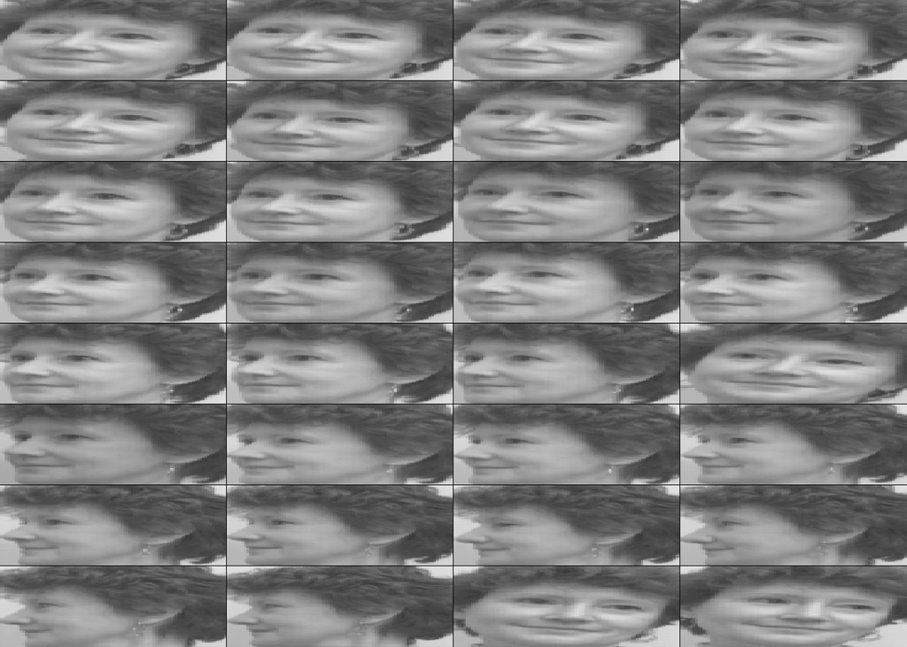

```r
ord <- order(y1)
par(mfrow = c(8, 4), mar = c(0, 0, 0, 0))
for (i in ord[1:32]) plot_face(faces[i, ])
```

### Problem 4

Consider the set $A=(0,2\pi)\times (-3,3)$ and the isometric manifold map
$$\Psi(x,y)= \begin{bmatrix}
\text{sign}(\pi-x)(1+\cos(x))\\ \sin(x)\\ y\end{bmatrix}$$
where $\text{sign}(z) = \begin{cases} 1 & z \ge 0 \\ -1 & \text{else.} \end{cases}$

Let
$$f(\vec{x}) =
d^{\mathcal{M}}(\vec{x},\vec{0})$$
be the geodesic distance between $\vec{x}$ and $\vec{0}$ along the manifold. Note, $\vec{0}$ is a point on the manifold so this is well-defined. Argue (mathematically or numerically) that $\|\mathcal{H}^{tan} f (\vec{0})\|_F^2 >0.$ For reference, the variable *problem4_coords* is a data matrix containing samples from this manifold. The corresponding geodesic distances are saved in the variable *problem4_geods*. A scatterplot of the data (color coded by their geodesic distance to the origin) in shown below.

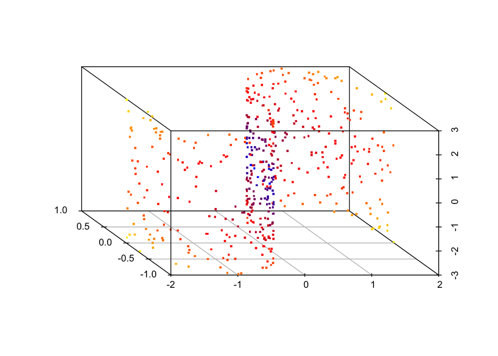

```r
scatterplot3d(problem4_coords[,1],problem4_coords[,2],problem4_coords[,3],
              color = myColorRamp(c("blue","red","yellow"),problem4_geods),
              angle = 120,
              xlab = "", ylab = "", zlab = "", pch = '.', cex.symbols = 3)
```

```r
# an interactive scatterplot of the data
# library(plotly)
# plot_ly(x=problem4_coords[,1],y=problem4_coords[,2],z=problem4_coords[,3],
#         marker = list(color =myColorRamp(c("blue","red","yellow"),problem4_geods),
#                       size = 3))
```

```r
library(numDeriv)

Psi <- function(u) c(sign(pi - u[1]) * (1 + cos(u[1])), sin(u[1]), u[2])
F   <- function(x) sqrt(sum(x^2))  # the geodesic is isometric so we can use the euclidean distance

u0  <- c(0, 0)
x0  <- Psi(u0)

J   <- jacobian(Psi, u0)

Hx  <- hessian(F, x0)
gF  <- grad(F, x0)

Hpsi1 <- hessian(function(u) Psi(u)[1], u0)
Hpsi2 <- hessian(function(u) Psi(u)[2], u0)
Hpsi3 <- hessian(function(u) Psi(u)[3], u0)

Htan <- t(J) %*% Hx %*% J + gF[1]*Hpsi1 + gF[2]*Hpsi2 + gF[3]*Hpsi3

fro  <- sqrt(sum(Htan^2))
skew <- max(abs(Htan - t(Htan)))

print(list(Frobenius_norm=as.numeric(fro),
           Symmetry_violation=as.numeric(skew),
           H_tangent=Htan))
```

```
## $Frobenius_norm
## [1] 0.7071074
##
## $Symmetry_violation
## [1] 0
##
## $H_tangent
##               [,1]          [,2]
## [1,] -4.999999e-01 -3.368656e-07
## [2,] -3.368656e-07  5.000011e-01
```

### Problem 5

Let ${\bf L} = {\bf D} - {\bf A}$ be the graph Laplacian. For data matrix ${\bf Y}\in\mathbb{R}^{N\times t}$ with rows $\vec{y}_1^T,\dots,\vec{y}_N^T$, verify the identity
$$tr({\bf Y}^T{\bf LY}) =
\frac{1}{2}\sum_{i=1}^N\sum_{j=1}^N {\bf A}_{ij}\|\vec{y}_i -
\vec{y}_j\|^2.$$
You may find the cyclic property of trace, $tr({\bf ABC}) = tr({\bf BCA}) = tr({\bf CAB}),$ to be helpful.

### Problem 6

In this problem, we will investigate the effect of noise on the performance of ISOMAP, HLLE, and Laplacian Eigenmaps. The variable *S$points* contains 2000 samples from a S-shaped sheet in $\mathbb{R}^3$. To assist with plotting, associated colors for each point are stored in the variable *S$colors*. For reference, the manifold is shown below..

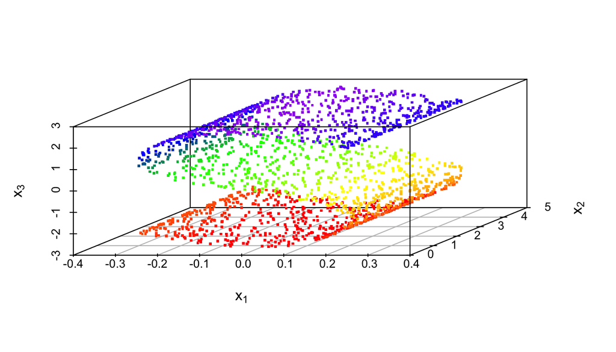

```r
scatterplot3d(S$points,
              color = S$colors,
              xlab = expression(x[1]), ylab = expression(x[2]), zlab = expression(x[3]),
              pch = '.',cex.symbols = 3)
```

1. Add independent $N(0,1)$ noise to each entry of *S$points*. Generate a two-dimensional representation of the data using ISOMAP with $k=30$ nearest neighbors. Repeat with $N(0,1/100)$ noise.

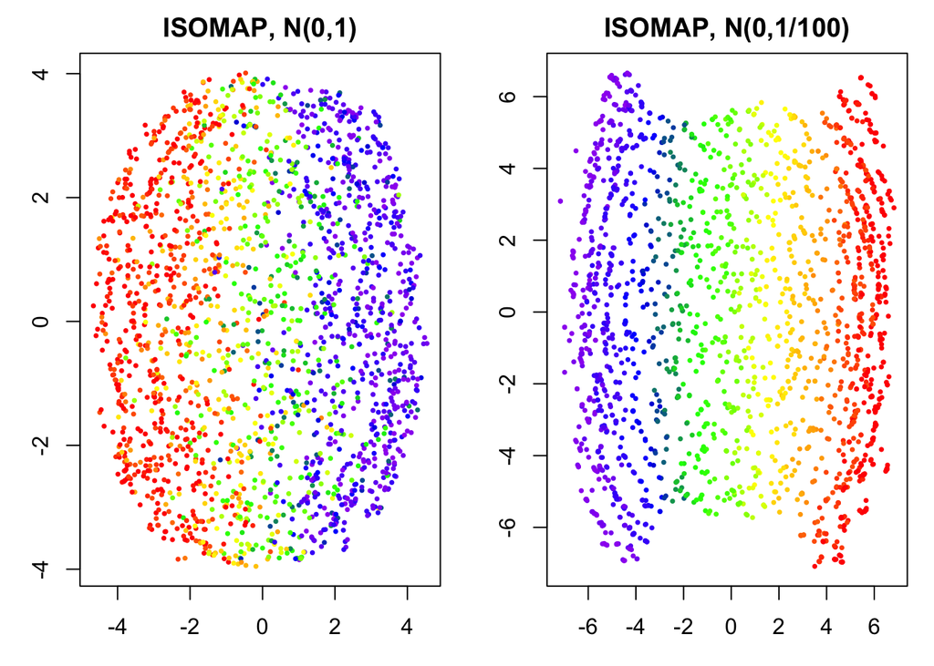

```r
X <- S$points; cols <- S$colors
iso_run <- function(s) do.isomap(X + matrix(rnorm(length(X), 0, s), nrow=nrow(X)), ndim=2, type=c("knn",30))$Y
Y1 <- iso_run(1)
Y01 <- iso_run(0.1)

par(mfrow=c(1,2), mar=c(3,3,2,1))
plot(Y1, col=cols, pch=16, cex=.5, xlab="", ylab="", main="ISOMAP, N(0,1)")
plot(Y01, col=cols, pch=16, cex=.5, xlab="", ylab="", main="ISOMAP, N(0,1/100)")
```

2. Repeat part a using HLLEs and Laplacian Eigenmaps. For both methods, use $k=30$ nearest neighbors. For Laplacian Eigenmaps, use kernelscale equal to 1.

```r
run_all <- function(s) {
  Xn <- X + matrix(rnorm(length(X), 0, s), nrow=nrow(X))
  hlle <- as.matrix(embed(dimRedData(as.data.frame(Xn)), "HLLE", knn=30, ndim=2)@data@data[,1:2])
  le   <- do.lapeig(Xn, ndim=2, type=c("knn",30), kernelscale=1)$Y
  list(hlle=hlle, le=le)
}

R1  <- run_all(1)
```

[output not shown]

```r
R01 <- run_all(0.1)
```

[output not shown]

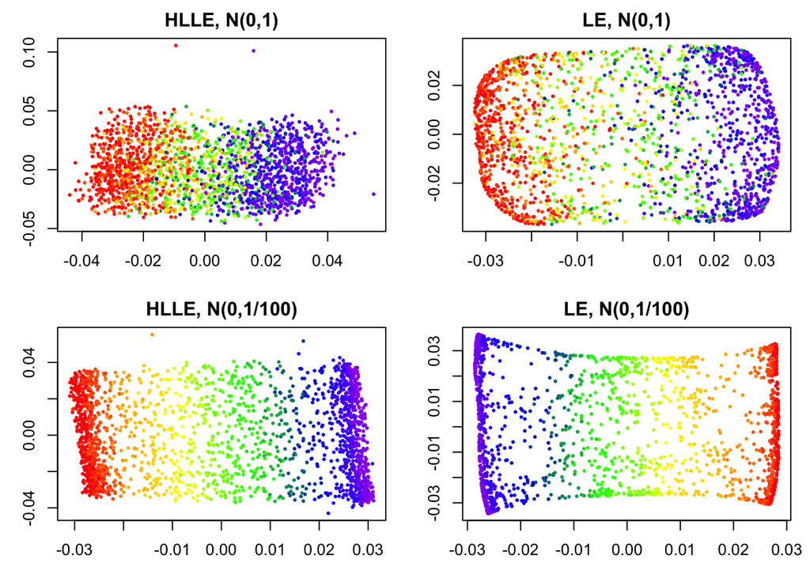

```r
par(mfrow=c(2,2), mar=c(3,3,2,1))
plot(R1$hlle,  col=cols, pch=16, cex=.5, xlab="", ylab="", main="HLLE, N(0,1)")
plot(R1$le,    col=cols, pch=16, cex=.5, xlab="", ylab="", main="LE, N(0,1)")
plot(R01$hlle, col=cols, pch=16, cex=.5, xlab="", ylab="", main="HLLE, N(0,1/100)")
plot(R01$le,   col=cols, pch=16, cex=.5, xlab="", ylab="", main="LE, N(0,1/100)")
```